# Reliability Growth Analysis

## Introduction

**Reliability Growth Analysis (RGA)** is an important part of reliability engineering, focused on improving system reliability during development and testing. By analyzing failure data, RGA helps engineers identify trends, estimate reliability parameters, and track improvements over time. These insights are essential for assessing the impact of design changes, guiding engineering decisions, and managing risks effectively.

## The Crow-AMSAA Model

The Army Materiel Systems Analysis Activity model by Crow **(Crow-AMSAA)** takes failure behavior as a **Non-Homogeneous Poisson Process (NHPP)** governed by a power law, making the model particularly effective for systems undergoing reliability growth due to continuous improvements.

The Crow-AMSAA model is a statistical model that characterizes the relationship between the cumulative number of failures and cumulative time as the following:

$$N(t) = \lambda\, t^{\beta}$$

where $N(t)$ denotes the cumulative number of failures by time $t$, $\lambda$ is a scaling parameter, and $\beta$ is the shape parameter.

The shape parameter $\beta$ indicates whether the system’s reliability is improving or deteriorating.

- If $\beta$ < 1, then the system is improving (reliability is growing, the failure rate is decreasing).
- If $\beta$ = 1, then there is no change in reliability (the system is stable).
- If $\beta$ > 1, then reliability is worsening (the failure rate is increasing).

### Example

First, load the package:

```r
library(ReliaGrowR)
```

Next, set up some time and failure data:

```r
times <- c(100, 200, 300, 400, 500)
failures <- c(1, 2, 1, 3, 2)
```

Then run the rga and plot the results:

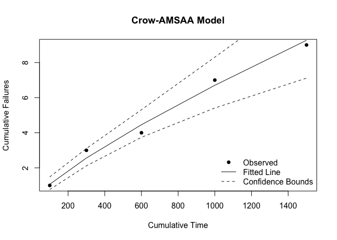

```r
result <- rga(times, failures)
plot(result, main = "Crow-AMSAA Model", xlab = "Cumulative Time", ylab = "Cumulative Failures")
```

The plot shows the cumulative failures on the y-axis and cumulative time on the x-axis, with a fitted curve indicating the reliability growth trend.

## The Piecewise NHPP Model

**The Piecewise NHPP model** is an extension of the standard NHPP model that includes different segments or phases of time that follow separate failure distributions. This model is particularly useful when a system experiences changes in failure behavior over different development phases, such as the initial, interim and final phases of a development process.

For a Piecewise NHPP model, the cumulative number of failures is modeled as a piecewise function, where each segment has its own parameters. Formally, for time t within phase i, the relationship between the cumulative number of failures and cumulative time is given by:

$$N_i(t) = N(t_{i-1}) + \lambda_i (t - t_{i-1})^{\beta_i}, \, \text{for }
t_{i-1} < t \leq t_i$$

where $N_i(t)$ is the cumulative number of failures by time $t$ in phase $i$, $\lambda_i$ is the scale parameter for phase $i$, and $\beta_i$ is the shape parameter for phase $i$.

### Example

To use the Piecewise NHPP model in ReliaGrowR, first, set up some time and failure data and specify a breakpoint:

```r
times <- c(25, 55, 97, 146, 201, 268, 341, 423, 513, 609, 710, 820, 940, 1072, 1217)
failures <- c(1, 1, 2, 4, 4, 1, 1, 2, 1, 4, 1, 1, 3, 3, 4)
breaks <- 500
```

Then run the rga and plot the results:

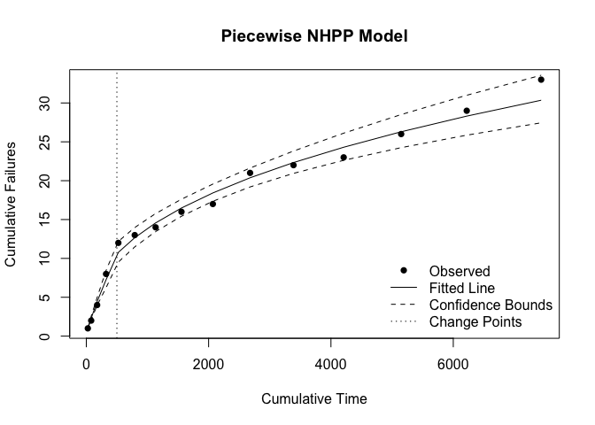

```r
result <- rga(times, failures, model_type = "Piecewise NHPP", breaks = c(breaks))
plot(result, main = "Piecewise NHPP Model", xlab = "Cumulative Time", ylab = "Cumulative Failures")
```

## The Piecewise NHPP with Change Point Detection

The Piecewise NHPP with **Change Point Detection** is an advanced model to identify changes in failure behavior and model system reliability. This method builds on the Piecewise NHPP model by introducing the concept of change points, which represent the time when the underlying failure behavior changes. Detection of change points involves statistical techniques that analyze failure data to automatically identify when the behavior changes, allowing for a more precise segmentation of the model into different distributions.

### Example

To use the Piecewise NHPP with Change Point Detection in ReliaGrowR, use the `rga` function with the model type set to “Piecewise NHPP” and breaks set to NULL. The function will automatically detect change points based on the provided failure data. First, set up some time and failure data:

```r
times <- c(25, 55, 97, 146, 201, 268, 341, 423, 513, 609, 710, 820, 940, 1072, 1217)
failures <- c(1, 1, 2, 4, 4, 1, 1, 2, 1, 4, 1, 1, 3, 3, 4)
```

Then run the rga and plot the results:

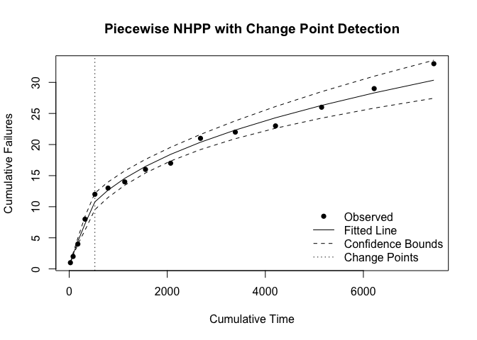

```r
result <- rga(times, failures, model_type = "Piecewise NHPP")
plot(result, main = "Piecewise NHPP with Change Point Detection", xlab = "Cumulative Time", ylab = "Cumulative Failures")
```

## The Duane Model

**The Duane model** provides a simple and graphical way to observe and analyze whether failure rates are improving as changes are made to a product or system. The Duane Model is a log-log plot of the cumulative Mean Time Between Failures (MTBF) vs cumulative time.

The slope of the line on the plot indicates the rate of reliability growth:

- A positive slope means that the system is improving (reliability is growing, the failure rate is decreasing).
- A zero slope means there is no change in reliability (the system is stable).
- A negative slope indicates that reliability is worsening (the failure rate is increasing).

To use the Duane Model in ReliaGrowR, use the `duane_plot` function. This function takes a a vector of failure times and a vector of failure counts, and generates a log-log plot of cumulative MTBF vs cumulative time.

### Example

First, set up some time and failure data:

```r
times <- c(100, 200, 300, 400, 500)
failures <- c(1, 2, 1, 3, 2)
```

Then fit the model and plot the results:

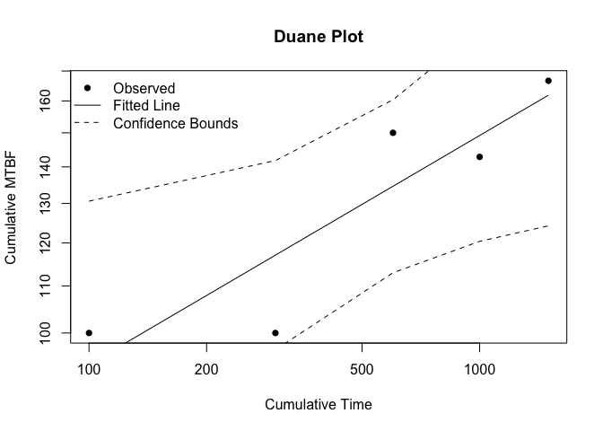

```r
fit <- duane(times, failures)
plot(fit, main = "Duane Plot", xlab = "Cumulative Time", ylab = "Cumulative MTBF")
```

The plot shows the cumulative MTBF on the y-axis and cumulative time on the x-axis, with a fitted line indicating the reliability growth trend.

## Goodness of Fit

Goodness of fit plots help assess how well a model matches the observed data. Two key functions are `qqplot.rga` for Q-Q plots and `ppplot.rga` for P-P plots. Both functions take an rga object as input.

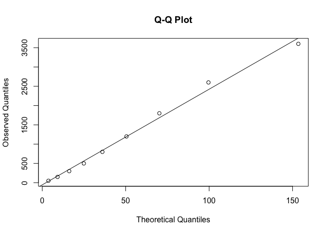

```r
times <- c(50, 100, 150, 200, 300, 400, 600, 800, 1000)
failures <- c(1, 1, 2, 2, 3, 4, 5, 6, 8)
result <- rga(times, failures)
qqplot.rga(result)
```

The `qqplot.rga` function produces a Q-Q plot that compares the quantiles of the observed data with those of the fitted model. A good fit is indicated when the points closely follow the 45-degree reference line.

Similarly, a P-P plot can be created with:

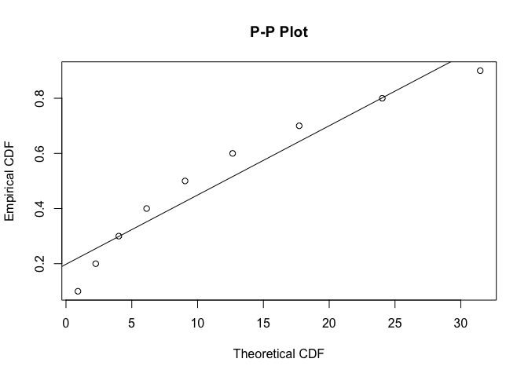

```r
ppplot.rga(result)
```

The `ppplot.rga` function compares the cumulative probabilities of the observed data with those of the fitted model. As with the Q-Q plot, a good fit is indicated when the points closely follow the 45-degree line.

## Data Conversion

Reliability data can be recorded in different formats, such as exact failure times, right-censored times, or failure times grouped into intervals. The `weibull_to_rga` utility function converts data from the format used in the WeibullR package into the format required for RGA analysis in ReliaGrowR. It accepts a vector of failure times and optional vectors of right-censored (suspension) times and interval-censored times, then returns a data frame with cumulative times and failure counts suitable for use with the rga function.

For example, consider the following dataset with failure times, right-censored times, and interval-censored times:

```r
failures <- c(100, 200, 200, 400)
suspensions <- c(250, 350, 450)
interval_starts <- c(150, 300)
interval_ends <- c(180, 320)
```

The data can be converted using `weibull_to_rga`:

```r
result <- weibull_to_rga(failures, suspensions, interval_starts, interval_ends)
```

The resulting data frame contains cumulative times and failure counts, which can then be passed directly to the `rga` function for reliability growth analysis.

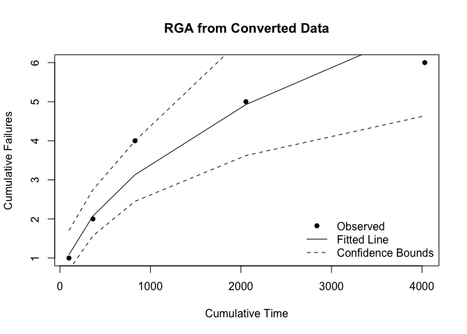

```r
fit <- rga(result$CumulativeTime, result$Failures)
plot(fit, main = "RGA from Converted Data", xlab = "Cumulative Time", ylab = "Cumulative Failures")
```

## Summary

RGA provides a powerful statistical framework for tracking and predicting how a system’s reliability evolves throughout development. Models like Crow-AMSAA, Piecewise NHPP, and the Duane Model allow engineers and analysts to quantify improvements (or regressions) in reliability, understand system behavior across development phases, detect significant shifts in failure patterns, and guide design changes and process improvements.